# 2018 NCAA Division 3 Cross-Country Team Predictions and Analysis

Sean Fischer and Ben Wach

November 16, 2018

## Introduction

It is that time of year again: nationals week. 32 teams have been chosen to travel to Winneconne, Wisconsin to compete for the national title on Saturday. Some of those teams have a better shot than others to come home with a trophy. Here we outline a set of predictions for the big day based on our speed ratings for 70 different races, from Week 3 (9/14) to Week 11 (11/09).

## Women’s Race

### Who do the “experts” have on top?

There are two sets of expert ratings to which we are comparing our projections: the USTFCCCA Coaches’ Polls and FloTrack’s FloRatings.

This year, both rankings are pretty similar. The [USTFCCCA poll](http://www.ustfccca.org/2018/11/featured/2018-ncaa-diii-womens-cross-country-national-coaches-poll-week-8) has Johns Hopkins as a heavy favorite, receiving all 8 first place votes in the poll. Wash. U., SUNY Geneseo, and MIT, take the next three spots, with uniform votes from all eight coaches in the poll. Middlebury is fifth, receiving seven out of eight fifth place votes. Dickinson, Eau Claire, and Williams fall sixth, seventh, and eighth, but in close votes, as they received 209, 208, and 203 points respectively. Teams 9-13 are also close, with La Crosse (9th) and Chicago (13th) only separated by ten points. The takeaway here is that the top-four teams are seen as being stable and firmly ahead of the pack. However, there is a lack of consensus over who the dark horses are, suggesting that the coaches may not be giving any of the teams much of a chance of reaching the podium on Saturday.

[FloTrack](https://www.flotrack.org/rankings/6238242-2018-floxc-womens-team-rankings/29128-2018-floxc-rankings-nov-13th) has Hopkins ranked first, followed by Wash. U., MIT, and Geneseo in the podium positions. Middlebury, Williams, Eau Claire, Dickinson, Brandeis, and Claremont-Mudd-Scripps round out their top 10. The only two movers in these rankings, compared to last week, are Williams and Brandeis who switched spots after Williams beat Brandeis at the New England Regional (115 to 136). Johns Hopkins has been the perennial favorite all year for FloTrack, with the top-4 teams not changing their positions over the course of the season in their estimation.

### Who do we have on top?

The important story we have this year is just how good Johns Hopkins is. Our simulations give them just over a 93% chance of winning. Their chance of leaving with any trophy is 99.98%. While it is hard to predict an exact score in cross country, our projections have Hopkins scoring around 70 points on average, less than half that of the second-place team in our projections. This is Hopkins’s race to lose. They are so far ahead of the competition at this point that they could probably withstand two significant injuries and still win on Saturday.

The race for second is much more interesting. SUNY Geneseo, after a dominant performance in the Atlantic Regional, has a slim advantage over Wash. U. in our projections. We chalk this up to Geneseo’s more variable performances over the season. We have captured almost all of their races, some of which they’ve performed 1-5 as a clear second-best team, but in others as a more likely fourth-place finisher. Alternatively, we only have a handful of races in our set featuring Wash. U. However, even in these races, the Wash. U. women have performed consistently. We are pretty confident we know how they will perform on Saturday. In that sense, the race for second will come down to two important elements. First, the distance between Wash. U.’s Paige Lawler and Geneseo’s Elise Ramirez finishing places; we have Lawler and Ramirez as two of the five team participants this weekend. If Lawler can gap Ramirez by about 10 points, that could be enough to turn the tide in Wash. U.’s favor. Second, how packed up Geneseo’s 2-5 can run. At the Atlantic Regional, Geneseo’s second, third, fourth, and fifth runners finished third, fifth, sixth, and thirteenth. However, that group covered a 54 second spread. In a weak Atlantic Region with few dominant front runners the team looked impressive. But, in a dense nationals race, having their fifth runner about 15 seconds faster might be the deciding factor in the final order. Currently, we expect Geneseo’s fifth runner to finish about 3-4 seconds ahead of Wash. U.’s fifth runner, a slim margin that could shift significantly given the underlying uncertainty in our measures. With Geneseo’s fifth leading Wash. U.’s fifth (even though Wash. U.’s 2-5 might be better packed together) we have Geneseo finishing ahead of Wash. U. by ten points on average (160 to 169). Given the relatively unusual consistency, though, with which Wash. U.’s first three runners have performed in the races we have rated, the Bears may be one good day from their fifth runner away from moving up into second. An interesting artifact of the opposite performance history of these two teams: Wash. U. is about 4% more likely than Geneseo (99% to 95%) to leave Wisconsin with a trophy.

Eau Claire’s biggest competition for the last podium spot comes from Carleton and MIT in our projections. These two teams project to score around 294 and 306 points, respectively. Both of these teams, if they are to be successful on Saturday, are going to need to overcome the relative absence of a front-of-the-pack first runner. With their first women projected to score over twenty points for both teams, a lot rests on how dense and far up their packs can finish. If either team’s fifth runner can have a race close to their absolute best (if not their best), then they might just be able to squeak onto the podium. We would be remiss to overlook the squad from Middlebury, though. The Panthers stand as one of the meet’s biggest wildcards. Though our projections place them closer to ninth than fifth, and their performances have been quite consistent, their third runner did not begin racing until mid-October and has only raced twice. That runner, Abigail Nadler, is a three-time cross country All-American and finished seventh last year. Though she does not appear to be in that form by any means, her two races have trended upwards and an All-American finish from her could put them in podium contention.

The final important takeaway from our projections is that any team with a woman in the front of the pack has a chance to sneak onto the podium. Teams like RPI and Allegheny could potentially (as in 1-in-10,000 chance) make big jumps from where we have them projected and where they are ranked nationally because of big races from their best women and near-best performances from runners 3-5. Allegheny’s Emily Forner looks like a potential single-digit scorer, and while RPI lacks a true frontrunner, their top two runners have both put out races that would likely score them fewer than 80 points through two runners, which could be a difference maker on the National stage.

Projected results for the 2018 NCAA Division 3 Women’s Cross Country Championships based on 10,000 simulations.

| School | Average Finish | Firsts | Seconds | Thirds | Fourths | Podiums | Average Points | Lower Point Threshold | Upper Point Threshold | Finish Rank |
| --- | --- | --- | --- | --- | --- | --- | --- | --- | --- | --- |
| Johns Hopkins | 1.0773 | 9314 | 607 | 73 | 4 | 9998 | 69.2386 | 13.71162 | 124.7656 | 1 |
| SUNY Geneseo | 2.5637 | 610 | 5227 | 3089 | 578 | 9504 | 161.3825 | 57.19703 | 265.5680 | 2 |
| Washington U. | 2.6074 | 74 | 4057 | 5610 | 241 | 9982 | 169.4900 | 121.56910 | 217.4109 | 3 |
| Wis.-Eau Claire | 4.8456 | 0 | 26 | 501 | 4315 | 4842 | 261.5574 | 197.45157 | 325.6632 | 4 |
| Carleton | 6.2226 | 0 | 20 | 221 | 1793 | 2034 | 293.2104 | 206.35431 | 380.0665 | 5 |
| MIT | 6.9213 | 0 | 21 | 171 | 1291 | 1483 | 306.9006 | 210.68549 | 403.1157 | 6 |
| Middlebury | 9.7215 | 0 | 0 | 20 | 235 | 255 | 356.4679 | 255.65435 | 457.2814 | 7 |
| Wis.-La Crosse | 10.6304 | 0 | 0 | 23 | 216 | 239 | 368.2165 | 251.23414 | 485.1989 | 8 |
| Wheaton (Ill.) | 10.7504 | 0 | 0 | 1 | 54 | 55 | 373.8857 | 294.93467 | 452.8367 | 9 |
| Dickinson | 12.3495 | 0 | 0 | 0 | 28 | 28 | 395.1603 | 292.88535 | 497.4352 | 10 |
| RPI | 13.1436 | 0 | 17 | 115 | 421 | 553 | 400.2211 | 212.57848 | 587.8637 | 11 |
| St. Lawrence | 13.7331 | 1 | 13 | 87 | 360 | 461 | 409.2877 | 217.99412 | 600.5813 | 12 |
| U. of Chicago | 13.6253 | 0 | 0 | 0 | 4 | 4 | 412.2533 | 315.84757 | 508.6590 | 13 |
| Brandeis | 13.6618 | 0 | 0 | 2 | 26 | 28 | 412.7739 | 314.44151 | 511.1063 | 14 |
| Williams | 14.9750 | 0 | 0 | 0 | 0 | 0 | 429.7710 | 353.58006 | 505.9619 | 15 |
| Rochester | 15.3041 | 0 | 7 | 51 | 253 | 311 | 432.2666 | 232.04630 | 632.4869 | 16 |
| Tufts | 15.9344 | 0 | 0 | 0 | 4 | 4 | 442.5329 | 323.78076 | 561.2850 | 17 |
| Nebraska Wesleyan | 17.8912 | 0 | 0 | 0 | 0 | 0 | 467.4018 | 395.94774 | 538.8559 | 18 |
| Allegheny | 17.7539 | 1 | 3 | 23 | 104 | 131 | 467.9341 | 282.51954 | 653.3487 | 19 |
| Claremont-Mudd-Scripps | 19.0292 | 0 | 0 | 0 | 0 | 0 | 483.3880 | 400.66077 | 566.1152 | 20 |
| Wartburg | 19.0994 | 0 | 0 | 0 | 7 | 7 | 485.4785 | 347.02393 | 623.9331 | 21 |
| Carnegie Mellon | 20.8315 | 0 | 2 | 13 | 66 | 81 | 516.3875 | 294.78204 | 737.9930 | 22 |
| Hope | 22.1012 | 0 | 0 | 0 | 0 | 0 | 526.2921 | 448.77755 | 603.8066 | 23 |
| Emory | 23.7681 | 0 | 0 | 0 | 0 | 0 | 551.7063 | 436.75090 | 666.6617 | 24 |
| Bates | 24.5765 | 0 | 0 | 0 | 0 | 0 | 563.7567 | 482.07076 | 645.4426 | 25 |
| Oberlin | 26.1666 | 0 | 0 | 0 | 0 | 0 | 591.8685 | 449.43397 | 734.3030 | 26 |
| Pomona-Pitzer | 27.5892 | 0 | 0 | 0 | 0 | 0 | 607.2124 | 547.11903 | 667.3058 | 27 |
| Otterbein | 27.6215 | 0 | 0 | 0 | 0 | 0 | 611.5212 | 510.21844 | 712.8240 | 28 |
| Calvin | 28.0019 | 0 | 0 | 0 | 0 | 0 | 617.4534 | 527.25856 | 707.6482 | 29 |
| TCNJ | 27.8167 | 0 | 0 | 0 | 0 | 0 | 621.4454 | 480.83960 | 762.0512 | 30 |
| Centre | 28.6233 | 0 | 0 | 0 | 0 | 0 | 628.0019 | 539.63561 | 716.3682 | 31 |
| Baldwin Wallace | 29.0628 | 0 | 0 | 0 | 0 | 0 | 642.1928 | 523.84899 | 760.5366 | 32 |

### Historical comparison

Our average points scored for Johns Hopkins would be an improvement of about 27 points over last year’s total of 96 and would be the lowest winning point total since 2015, the first national championship this year’s seniors could have participated in. (The lowest total over that range was Williams’s 81 points in 2015.)

The projected margin of about 92 points victory would be in line with what is increasingly the trend in the women’s race. The 2015 race and the 2017 race were decided by 98 and 95 points respectively. The only blip in the short-term was the 2016 race, which still had a winning margin of 74 points. The projected margin between second and third would also continue a recent trend of highly competitive races for the second podium spot (3 points in 2015, 12 points in 2016, and 11 points in 2016). However, the large projected gap between third and fourth would be a move away from what we have seen in the last three years. Over that period the differences between third and fourth have been 6 points (2015), 18 points (2016), and 8 points (2017). This year we expect the gap to be over 90 points.

Otherwise, this year’s national championship is shaping up to match recent history. We are expecting to see the 11th place team be the first to cross the 400 point barrier, in line with the results from 2015-2017. Similarly, the 500 point threshold is expected be crossed by the twenty-second team, a mark in line with the last three years when this point total was crossed by positions 20, 21, and 21. These two assessments suggest that the majority of the competition this year is relatively generic. The exciting and isolated race up-front is a unique feature, but we don’t see the field as a whole becoming more competitive.

## Men’s Race

### Who do the “experts” have on top?

As with the women’s race, we are comparing our projections to the USTFCCCA Coaches’ Poll and FloTrack’s FloRatings.

The [USTFCCCA Poll](http://www.ustfccca.org/2018/11/featured/2018-ncaa-diii-mens-cross-country-national-coaches-poll-week-8) for the men has only one team all eight voting coaches could agree upon: North Central. The Cardinals are a unanimous top choice and have been all season. Behind them, there is no uniform consensus on the order. In a close vote, Wash. U. is ranked second, followed by RPI, who jumped seven spots after a rebound performance at the Atlantic Regional. UW La Crosse and Calvin round out the top 5, each receiving at least 230 points. Teams 6-9 also form a close pack, with Carnegie Mellon, Haverford, and Amherst netting 209, 207, and 206 points respectively. Geneseo and Pomona-Pitzer round out the top 10, as they begin a cluster of teams from ninth to fourteenth that garnered between 185 and 153 points.

### Who do we have on top?

Our projections nicely converge with these *expert* rankings for some teams, but not all. Our projections suggest that some teams are being criminally mis-ranked.

North Central is not one of those teams. The unanimous expert pick to win the national title on Saturday, North Central brings home the title in over 99% of our simulations. And it likely won’t be close.

Teams 2-5 in our projections are UW La Crosse, Wash. U., RPI, and Calvin. Each of these teams is projected to score between 235 and 286 points. (Remember, point projections are a tricky thing and should be taken with a healthy dose of skepticism and with attention paid to the projected uncertainty of the estimates.) It would be nice to say one of these teams is significantly better positioned than any of the others, but when we look at the likely range of possibilities, we see that all have similar uncertainty windows, with maybe Calvin being the most likely to experience an extreme fluctuation. The takeaway, then, should be that the race for the podium is going to be tight and come down to where these teams’ fifth runners finish. RPI and Calvin have the fifth runners that project to be about 9 seconds ahead of La Crosse and Wash. U.’s fifth runners, both of whom are also projected to finish together. The La Crosse fifth runner has been very consistent across races we have rated, so we don’t expect a necessarily large jump from him. The Wash. U. fifth, alternatively, has shown some range, and may be able to run with or ahead of RPI and Calvin’s fifths on a good day. That being said, the RPI fifth has had a similar range of performance, but with that slightly higher upside. Finally, the Calvin fifth has shown the most upside of the set, but that also means they have the greatest chance of running just below their projection.

It is also worth mentioning here that RPI’s potential first finisher, Grant O’Connor, has been racing almost the entire season with an apparent set back. O’Connor was a preseason favorite for the individual title, but did not win a race till the Atlantic Regional, which involved breaking away late from a pack fighting against poor course conditions. This improved performance, especially in comparison to the performance at Rowan’s Interregional Border Battle in Week 7, has us suspecting that O’Connor is finally starting to track upwards towards preseason expectations. There is still a long ways to go, though; the course in Wisconsin has traditionally been well maintained and usually generates races that are fast from the gun. Will O’Connor be able to hang for an 8k that is hard the whole way?

Similarly, Wash. U.’s second runner this year, David O’gara, was the ninth-place finisher a year ago. This year, he has not been nearly as successful, having just finished 36th at the Midwest Regional, which was his worst race since his sophomore year. O’gara’s wide range of outcomes this year has led to him having a large amount of variance around his projected ability. His likely outcomes range almost a whole minute of race time. Obviously, Wash. U.’s performance is highly tied to what end of the spectrum of his likely performances O’gara runs towards. However, given his most recent performance, O’gara running towards his best-ever performances seems like an unlikely.

Behind Calvin, another cluster of teams appears in our projections. Carnegie Mellon, Amherst, Warburg, and Haverford are all projected to score between 304 and 333 points and have non-zero probabilities of finishing on the podium. Carnegie Mellon and Amherst, in fact, have probabilities over 20%. These teams are in an odd place where they lack a dominant front runner and have solid fifth runners who are only about 10 seconds behind the fifths from La Crosse, Wash. U., RPI, and Calvin. But, these teams have greater amounts of variance in their performances as well, leaving the door slightly more open than one may expect. If any one of these teams has a whole-team race at their runners’ bests, they should unsurprisingly threaten for a podium spot.

Again, we should take some time to consider the role of injury in our projections. Haverford’s Dylan Gearinger did not run in the Mideast Regional, which excluded him from our projections. However, he still may participate at NCAA’s. At Pre-Nationals, Gearinger finished third behind the top two from North Central. He was only a second behind Matt Osmulski that day. Matt Osmulski is projected to run around a 191 speed rating on our scale with low-to-moderate variance.[^1] If we plug Gearinger back into the Haverford lineup at a 188 speed rating with high variance, they would easily have one of the best 1-5 lineups after North Central. Their best comparison at that point would probably be RPI or Calvin. Keep an eye out for Gearinger early. If he does race and finishes well within what his prior races suggest he can, Haverford will become a team that can make a strong push to the podium.

The last group worth mentioning is the pack from Carleton, the tenth best team in our projections, to UW Stout, the fifteenth best team in our projections. Included between these two poles are Johns Hopkins, Pomona-Pitzer, Geneseo, and Williams. The projected point spread for this group is only 22 points! It is highly unlikely that any of these teams threaten for a podium spot, although they all have non-zero chances of making it into the top four. What is more interesting is considering the possibility that one or two of these teams has great days and finishes between sixth and ninth. Such a jump is not unreasonable given the amount of variance in their performances over the course of the season.

### Historical comparison

The 76 points North Central is projected to score would actually be the worst total of their current streak of consecutive national titles, as they scored 57 and 60 in 2017 and 2016 respectively. That being said, Eau Claire scored 135 to win a close race against Williams (144) in 2015. The highest we think North Central could score (131) is still lower than this total, emphasizing, once again, just how good this current team is.

While their projected point total is not the best of their current run, North Central’s projected margin of 159 points would be better than their 2016 and 2017 titles. In those two championships, they *only* won by 144 and 139 points. The projected differences from second to third and third to fourths would fall in line with the trend since 2015 of close races for the final 2 to 3 podium spots. In 2015, Geneseo claimed third by only two points over St. Olaf. In 2016, Geneseo finished in second, beat Eau Claire by 5, and Wash. U. by 12. What we might think of being odd, the close margin from second to tenth in our projections, is also not that odd. Over the last three championships, we have seen 2-10 spreads of 159, 148, and 122 points. This year we expect that margin to be about 154 points.

If anything, the oddity of this race is that we expect to see the 400 point threshold crossed 2-3 spots earlier than normal. Since 2015, that line has been crossed by 15th, 17th, and 15th place teams. We think it might happen around 13th place. Does that mean the race is less competitive than in other years? We don’t think so. A better perspective might be that the gap between second and fifteenth is shrinking, meaning that few teams are able to bring in whole packs early, leading to a faster gain in total points.

Projected results for the 2018 NCAA Division 3 Men’s Cross Country Championships based on 10,000 simulations.

| School | Average Finish | Firsts | Seconds | Thirds | Fourths | Podiums | Average Points | Lower Point Threshold | Upper Point Threshold | Finish Rank |
| --- | --- | --- | --- | --- | --- | --- | --- | --- | --- | --- |
| North Central (Ill.) | 1.0059 | 9947 | 49 | 3 | 0 | 9999 | 76.3087 | 21.06978 | 131.5476 | 1 |
| Wis.-La Crosse | 3.6178 | 7 | 2639 | 2929 | 2062 | 7637 | 234.9625 | 169.05434 | 300.8707 | 2 |
| Washington U. | 4.2702 | 23 | 3004 | 1949 | 1479 | 6455 | 242.6811 | 132.71632 | 352.6459 | 3 |
| RPI | 5.0274 | 5 | 1597 | 1660 | 1711 | 4973 | 261.5049 | 160.56111 | 362.4487 | 4 |
| Calvin | 6.4178 | 6 | 1185 | 1163 | 1222 | 3576 | 286.3844 | 155.62185 | 417.1470 | 5 |
| Carnegie Mellon | 7.1976 | 2 | 382 | 633 | 999 | 2016 | 304.2635 | 198.48427 | 410.0427 | 6 |
| Amherst | 8.2911 | 9 | 661 | 649 | 725 | 2044 | 319.3953 | 178.13586 | 460.6547 | 7 |
| Wartburg | 8.1831 | 1 | 247 | 443 | 635 | 1326 | 320.3023 | 208.71502 | 431.8896 | 8 |
| Haverford | 8.8830 | 0 | 76 | 210 | 457 | 743 | 333.1060 | 230.54598 | 435.6660 | 9 |
| Carleton | 12.3903 | 0 | 12 | 36 | 90 | 138 | 388.1878 | 264.34605 | 512.0296 | 10 |
| Johns Hopkins | 12.9201 | 0 | 7 | 28 | 63 | 98 | 396.0953 | 281.26139 | 510.9292 | 11 |
| Pomona-Pitzer | 12.9599 | 0 | 3 | 17 | 62 | 82 | 396.4189 | 282.04185 | 510.7959 | 12 |
| SUNY Geneseo | 13.6157 | 0 | 66 | 104 | 169 | 339 | 405.4758 | 248.80109 | 562.1505 | 13 |
| Williams | 13.7102 | 0 | 18 | 41 | 81 | 140 | 407.1171 | 279.72325 | 534.5109 | 14 |
| Wis.-Stout | 13.9314 | 0 | 18 | 48 | 70 | 136 | 410.2293 | 272.94194 | 547.5167 | 15 |
| MIT | 14.5189 | 0 | 6 | 17 | 41 | 64 | 420.2395 | 288.25837 | 552.2206 | 16 |
| Middlebury | 14.5006 | 0 | 30 | 69 | 132 | 231 | 420.3053 | 252.13677 | 588.4738 | 17 |
| St. Olaf | 18.6075 | 0 | 0 | 0 | 0 | 0 | 482.5815 | 365.78370 | 599.3793 | 18 |
| Otterbein | 19.2583 | 0 | 0 | 0 | 0 | 0 | 492.3943 | 391.23464 | 593.5540 | 19 |
| Wis.-Eau Claire | 19.8364 | 0 | 0 | 1 | 1 | 2 | 503.1015 | 357.39728 | 648.8057 | 20 |
| Claremont-Mudd-Scripps | 20.0369 | 0 | 0 | 0 | 0 | 0 | 505.5839 | 387.92900 | 623.2388 | 21 |
| U. of Chicago | 21.1424 | 0 | 0 | 0 | 0 | 0 | 520.9841 | 437.60346 | 604.3647 | 22 |
| Rhodes | 22.3220 | 0 | 0 | 0 | 0 | 0 | 542.1188 | 435.88404 | 648.3536 | 23 |
| Oneonta | 23.8885 | 0 | 0 | 0 | 0 | 0 | 574.2178 | 429.64951 | 718.7861 | 24 |
| RIT | 24.2712 | 0 | 0 | 0 | 0 | 0 | 576.5895 | 479.16891 | 674.0101 | 25 |
| St. Thomas (Minn.) | 25.6629 | 0 | 0 | 0 | 0 | 0 | 608.7051 | 464.75608 | 752.6541 | 26 |
| Bates | 26.9827 | 0 | 0 | 0 | 1 | 1 | 648.4792 | 447.11806 | 849.8403 | 27 |
| Tufts | 27.4609 | 0 | 0 | 0 | 0 | 0 | 655.3003 | 470.97971 | 839.6209 | 28 |
| Berea | 28.6768 | 0 | 0 | 0 | 0 | 0 | 671.4580 | 578.04276 | 764.8732 | 29 |
| Emory | 29.2847 | 0 | 0 | 0 | 0 | 0 | 686.2019 | 596.09509 | 776.3087 | 30 |
| Case Western | 29.6590 | 0 | 0 | 0 | 0 | 0 | 697.9441 | 597.85362 | 798.0346 | 31 |
| DePauw | 29.4688 | 0 | 0 | 0 | 0 | 0 | 700.3458 | 562.72157 | 837.9700 | 32 |

## Meet Competitiveness

### Projected Point Totals

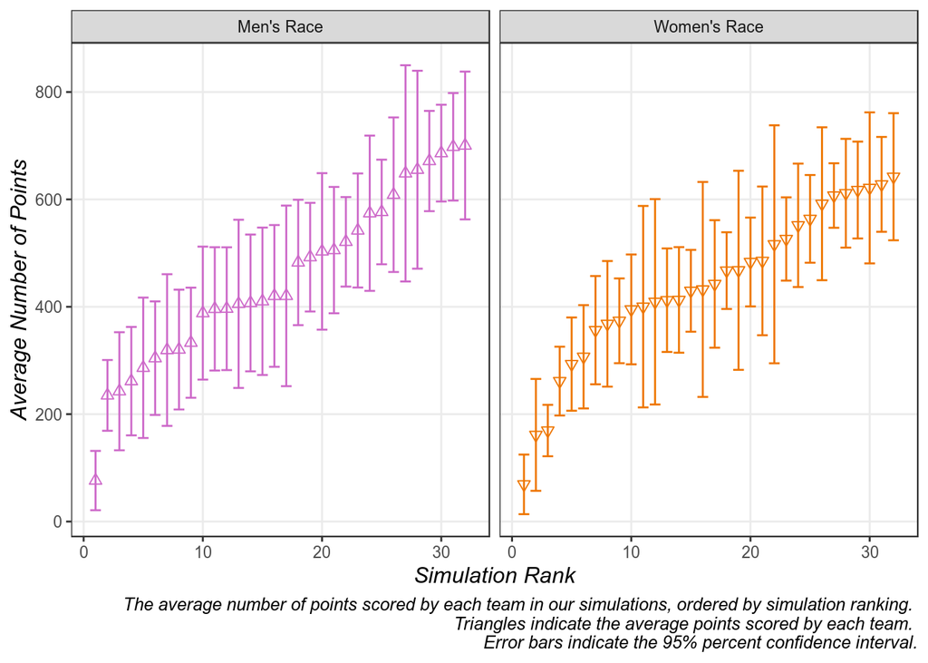

Given that both races feature historically dominant favorites, it is worth considering how competitive the two races are.

The men’s race, as we have already discussed, is not projected to be a competitive affair in regards to the race for the first place. North Central has a probability of winning another national championship that is greater than 99%. We see this projected dominance in a different way in the estimation of their projected point total. Over our simulations, North Central averaged just over 76 points. The next closest teams were over 200 points. However, even taking into account the uncertainty in our estimates, no other teams’ 95% confidence interval overlaps with that of North Central. This statistical point means that according to our estimate, we believe North Central’s score to be significantly different from those for all other teams.

After North Central, the men’s race breaks into two chase packs of eight teams each. The eight teams in each of these packs have similar average point values and confidence intervals, especially in the second chase pack. However, even though the two groups are clearly differentiable, the groups have confidence intervals that overlap, meaning that we should not be too surprised if any of these teams beat any others amongst the 16. However, for this type of leap-frogging to occur, we would need to see some teams have their best possible performances and some have their worst possible performances.

As for the women’s race, we’ve already established that there is a near certain winner in Johns Hopkins and then two teams, Geneseo and Wash. U., in a close race for second. We can see in the above figure that the these three teams are clearly differentiated from the other 29 teams. When we look at their confidence intervals, we notice that Geneseo has some substantial overlap with Hopkins’s interval, while Wash. U.‘s confidence interval only briefly overlaps with Hopkins’. The takeaway here is that according to our simulations, Geneseo has a greater chance of taking advantage of Hopkins not running to their expected potential than Wash. U.

However, Wash. U.’s expected point range is much tighter than Geneseo’s, as we detailed in our women’s preview. This wide range of uncertainty makes the race for second all the more interesting. It will not take a truly unexpected set of events for Geneseo to fall behind Wash. U. Yet, neither team is likely to be challenged for the their spot in the top three, an important difference from the men’s race.

After Geneseo and Wash. U. the women’s race breaks into a long chain of (relatively) equally dispersed teams. What will this mean for the competitiveness of the meet is not entirely clear. If teams perform to their average, there are only a few spots where leap-frogging could occur. But, if some teams perform dramatically differently from their average in our projections, which could reasonably happen as some teams have large amounts of uncertainty around them, we could see a few teams in the 10-15 range jumping into the top 10. They likely would not have a chance to compete for a podium spot, though, marking another important difference from the highly clustered men’s race. From this perspective, the women’s competition for the podium is a six-team affair, while the men’s is an eight- or nine-team affair.

### Probabilities of Finishing on the Podium

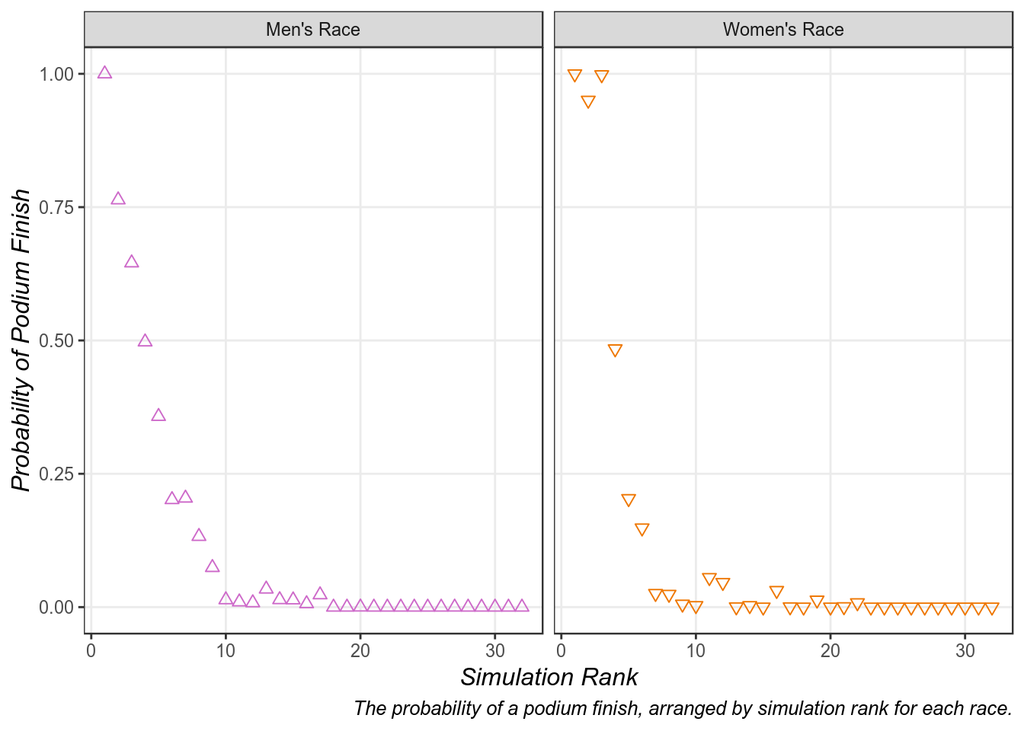

Another way of conceiving of race competitiveness is to measure the probability each team has of finishing on the podium. The above figure presents the probability of finishing on the podium for each team in the men’s and women’s championship based on our simulation results.

## How did we arrive at these results?

Our methodology begins by collecting race results. We convert raw results into standardized speed ratings via a mix of approaches, balancing various diagnostics to arrive at (what we hope is) the best possible estimate. These speed rating methods were developed and popularized by Bill Meylan of [TullyRunners.com](http://www.tullyrunners.com). We estimate these speed ratings over the course of the season and add them to our speed ratings from prior years. We then apply a weighting scheme that gives credence to runners’ most recent and best races to bootstrap a mean speed rating and the associted variance. With these measures, we simulate the NCAA team race 10,000 times, assuming that runners’ performances are drawn from a normal distribution with a mean and variance equal to the values calculated from the bootstrap. We use these individual simulations to calculate the team scores in each of the 10,000 simulated races. We report the average finishing place for each team, the number of times they finished in first, second, third, fourth, and on the podium at all. Additionally, we present the average number of points each team scored in our simulations. The final ranking we assign is based on the average number of points each team scores across the 10,000 simulations.

There are a few important limitations to your approach. First, we generally only projected NCAAs using teams’ lineups from regionals weekend. We have found in prior cases that these lineups very rarely change from regionals to nationals. However, this year we did include Johns Hopkins’ women’s runners who were held out of the regional. Second, our approach is based on a weighting scheme that we have developed, but are still in the process of tuning. Currently, we do not take into account the actual trajectory of prior years, instead choosing to downweight prior years’ observations as unlikely outliers. What this means is that we do not identify runners who consistently race better at the end of the year and then use that information to raise their projected scores. This makes it hard to take into account team- or individual-specific trends, such as consistent improvement late in the season. If athletes only generate one strong result, our scheme will take that into account, but still generate a projection below that mark, albeit it with greater uncertainty. Finally, we leverage no additional information, such as prior or forecasted race conditions, even though some teams and individuals have drastic performance changes when the course conditions deteriorate. For races that are entirely unrepresentative[^2], such as this year’s SUNYAC conference championship or early season races affected by extreme heat, we have dropped them from the bootstrapping procedure used to establish an initial estimate of each runner’s ability and variance.

[^1]: 1 speed rating point on our scale is equal to 4.4 seconds. Our zero point is 2,355 seconds.
[^2]: Here, we do not mean that a race was too fast or too slow, but rather too spread out or too condensed.